# Identifying spatially variable genes

Data Lab for ALSF

2026

## Objectives

- Introduce the `SpatialFeatureExperiment` and `Voyager` packages
- Demonstrate two methods for identifying spatially variable genes

## Set up

First we will load the `SpatialExperiment` package, as we have done before, as well as some familiar packages for plotting.

We’ll also set a random seed for reproducibility.

### Libraries

```r
# The main class we use for spatial transcriptomic data
suppressPackageStartupMessages({
  library(SpatialExperiment)
})

library(ggplot2)
library(patchwork)

# Set default ggplot2 theme
theme_set(theme_bw())
```

```r
set.seed(2026)
```

### Files

Wilms tumor data

```r
# define sample id we'll be analyzing
sample_id <- "SCPCS000190"

# data directory for this sample
data_dir <- file.path("data/wilms-tumor", sample_id, "normalized")

normalized_rds <- file.path(data_dir, "SCPCS000190_normalized.rds")
```

### Import

Let’s start by reading in the pre-processed SPE object:

```r
spe <- readr::read_rds(normalized_rds)
```

Let’s make sure the sample id is set correctly for later import:

```r
spe$sample_id <- sample_id
imgData(spe)$sample_id <- sample_id
```

Last time we calculated hvgs first, but this time let’s convert first, just to show that everything with spe works with sfe as well.

```r
sfe <- SpatialFeatureExperiment::toSpatialFeatureExperiment(spe) |>
  # flip the coordinates to match how we have been looking at them
  SpatialFeatureExperiment::mirror() |>
  # we have to flip the image again to match: it was upside down
  SpatialFeatureExperiment::mirrorImg()
```

## Identifying Highly Variable Genes

For the first part of this notebook, we are going to use the scran package to identify highly variable genes, just as we have done before. Many of the calculations we will be doing for spatial analysis are not particularly fast, so this will help us speed up calculations. But more practically, if a gene is not particularly variable overall, it is quite unlikely to be spatially variable, and we are not likely to get much signal from it.

```r
# model gene variance
gene_variance <- scran::modelGeneVar(sfe)

# calculate the top 2000 HVGs
hvg_vector <- scran::getTopHVGs(gene_variance, n = 2000)
```

```r
# filter the SPE to only include the highly variable genes
sfe <- sfe[hvg_vector, ]
```

Let’s look at the contents of the SFE:

```r
sfe
```

```
class: SpatialFeatureExperiment
dim: 2000 4149
metadata(2): resources spatialList
assays(2): counts logcounts
rownames(2000): ENSG00000163453 ENSG00000111341 ... ENSG00000163659 ENSG00000106034
rowData names(4): ID Symbol Type subsets_mito
colnames(4149): AAACAACGAATAGTTC-1 AAACAAGTATCTCCCA-1 ... TTGTTTGTATTACACG-1 TTGTTTGTGTAAATTC-1
colData names(21): in_tissue array_row ... local_outliers sizeFactor
reducedDimNames(0):
mainExpName: Gene Expression
altExpNames(0):
spatialCoords names(2) : pxl_col_in_fullres pxl_row_in_fullres
imgData names(4): sample_id image_id data scaleFactor

unit:
Geometries:
colGeometries: centroids (POINT)

Graphs:
SCPCS000190:
```

The first part looks pretty much the same as the SPE object, but you will notice a few extra slots in the summary:

- `unit`
- `Geometries`
- `colGeometries`
- `Graphs`

For now most of these are empty.

One thing you will see here is that the `SpatialFeatureExperiment` package is built from the start to accommodate multiple samples, so the graphs will be divided up by sample. We only have one, but we will see some consequences of this as we move forward.

The first thing we will do is to define contents for the Graphs

The next step is to define the graph that defines how cells are connected to each other. For Visium data, we can use `SpatialFeatureExperiment::findVisiumGraph()` which uses the known barcodes and their locations to define a graph that connects nearby spots. This is a nice shortcut, but for other kinds of spatial data (such as image-based Xenium data), we would have to use a function like `SpatialFeatureExperiment::findKNNGraph()` to find the nearest neighbors for each cell, and then define the graph based on that.

We will store that in the `colGraph` slot of the SFE object (this is one of the things we get from that package)

```r
#| error: true

# use the Visium barcodes to define the graph
SpatialFeatureExperiment::colGraph(
  sfe
) <- SpatialFeatureExperiment::findVisiumGraph(sfe)
```

```
Error in nb2listw(g, style = style, zero.policy = zero.policy) :
  Empty neighbour sets found (zero.policy: FALSE)
```

We get an error here because there are some isolated points in the graph, which is not allowed. We could ignore it by setting `zero.policy = TRUE`, but then we would have to deal with those points downstream as well, so it is probably better to just dropt them.

Instead we will use a feature to find debris cells. The distance cutoff here matters a lot, 300 seems to work well for this dataset with the resolution here, it does depend a lot on the units!

```r
sfe <- SpatialFeatureExperiment::findDebrisCells(sfe, distance_cutoff = 300)
```

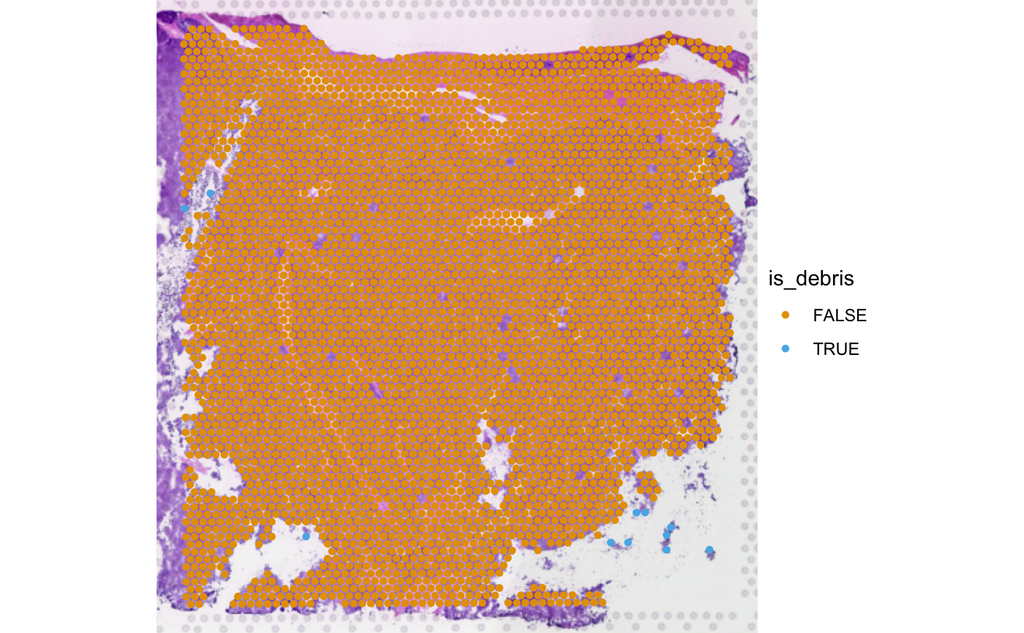

```r
Voyager::plotSpatialFeature(
  sfe,
  size = 1.5,
  features = "is_debris",
  image_id = "lowres"
)
```

```r
sfe <- sfe[, !sfe$is_debris]
```

Now we will make the colGraph again:

```r
SpatialFeatureExperiment::colGraph(
  sfe
) <- SpatialFeatureExperiment::findVisiumGraph(sfe)
```

Warnings about subgraphs are probably fine.

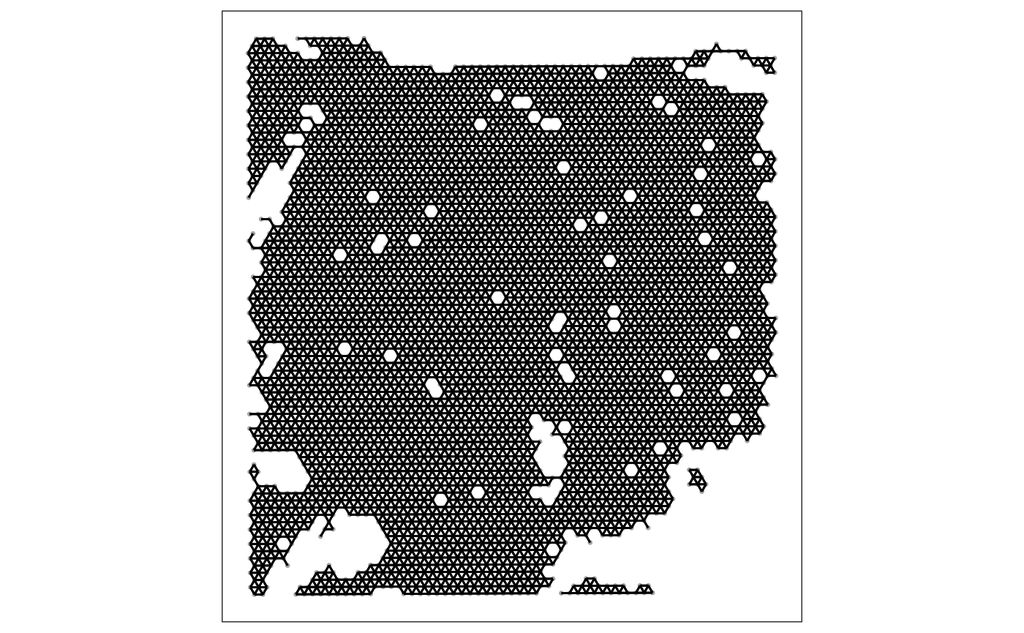

```r
Voyager::plotColGraph(sfe) +
  # the units are arbitrary, so let's leave them and the grid lines off
  theme(
    axis.ticks = element_blank(),
    axis.text = element_blank(),
    panel.grid = element_blank()
  )
```

## Identify Spatially Variable Genes

### Moran’s I

```r
sfe <- Voyager::runMoransI(sfe)
```

```r
rowData(sfe)
```

```
DataFrame with 2000 rows and 6 columns
                             ID      Symbol            Type subsets_mito moran_SCPCS000190 K_SCPCS000190
                    <character> <character>     <character>    <logical>         <numeric>     <numeric>
ENSG00000163453 ENSG00000163453      IGFBP7 Gene Expression        FALSE          0.612310       2.47633
ENSG00000111341 ENSG00000111341         MGP Gene Expression        FALSE          0.725796       3.35589
ENSG00000108821 ENSG00000108821      COL1A1 Gene Expression        FALSE          0.644116       2.89770
ENSG00000168542 ENSG00000168542      COL3A1 Gene Expression        FALSE          0.676594       2.92087
ENSG00000149591 ENSG00000149591       TAGLN Gene Expression        FALSE          0.787814       4.79764
...                         ...         ...             ...          ...               ...           ...
ENSG00000154330 ENSG00000154330        PGM5 Gene Expression        FALSE        0.00971519       3.05122
ENSG00000115419 ENSG00000115419         GLS Gene Expression        FALSE        0.01506747       2.86853
ENSG00000138495 ENSG00000138495       COX17 Gene Expression        FALSE        0.14483136       3.28024
ENSG00000163659 ENSG00000163659      TIPARP Gene Expression        FALSE       -0.00235874       5.51232
ENSG00000106034 ENSG00000106034       CPED1 Gene Expression        FALSE        0.05964266      25.64664
```

You’ll notice that the new column names include the `sample_id`, which is a bit annoying, but it is necessary to keep things separate if we have multiple samples. We’ll make sure to set that as a variable so we can reuse it as needed.

Let’s first look at the distribution of Moran’s I values across all (highly variable) genes:

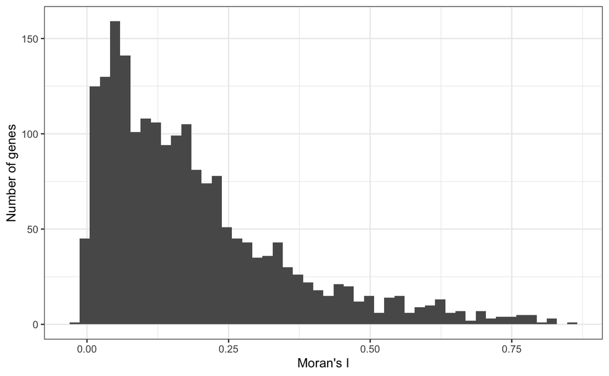

```r
rowData(sfe) |>
  as.data.frame() |>
  ggplot(aes(x = .data[[paste0("moran_", sample_id)]])) +
  geom_histogram(bins = 50) +
  labs(
    x = "Moran's I",
    y = "Number of genes"
  )
```

We get a value there, but no measure of significance.

`moran.test` is relatively fast, so we can do that first (though it is not likely to be as accurate, as it does not account for the structure of the graph).

```r
sfe <- Voyager::runUnivariate(
  sfe,
  type = "moran.test",
  BPPARAM = BiocParallel::MulticoreParam(4)
)

rowData(sfe)
```

```
DataFrame with 2000 rows and 13 columns
                             ID      Symbol            Type subsets_mito moran_SCPCS000190 K_SCPCS000190 moran.test_statistic_SCPCS000190 moran.test_p.value_SCPCS000190 moran.test_alternative_SCPCS000190 moran.test_method_SCPCS000190
                    <character> <character>     <character>    <logical>         <numeric>     <numeric>                        <numeric>                      <numeric>                        <character>                   <character>
ENSG00000163453 ENSG00000163453      IGFBP7 Gene Expression        FALSE          0.612310       2.47633                          65.4460                              0                            greater        Moran I test under r..
ENSG00000111341 ENSG00000111341         MGP Gene Expression        FALSE          0.725796       3.35589                          77.5792                              0                            greater        Moran I test under r..
ENSG00000108821 ENSG00000108821      COL1A1 Gene Expression        FALSE          0.644116       2.89770                          68.8477                              0                            greater        Moran I test under r..
ENSG00000168542 ENSG00000168542      COL3A1 Gene Expression        FALSE          0.676594       2.92087                          72.3182                              0                            greater        Moran I test under r..
ENSG00000149591 ENSG00000149591       TAGLN Gene Expression        FALSE          0.787814       4.79764                          84.2208                              0                            greater        Moran I test under r..
...                         ...         ...             ...          ...               ...           ...                              ...                            ...                                ...                           ...
ENSG00000154330 ENSG00000154330        PGM5 Gene Expression        FALSE        0.00971519       3.05122                         1.063886                    1.43690e-01                            greater        Moran I test under r..
ENSG00000115419 ENSG00000115419         GLS Gene Expression        FALSE        0.01506747       2.86853                         1.635736                    5.09474e-02                            greater        Moran I test under r..
ENSG00000138495 ENSG00000138495       COX17 Gene Expression        FALSE        0.14483136       3.28024                        15.501347                    1.69847e-54                            greater        Moran I test under r..
ENSG00000163659 ENSG00000163659      TIPARP Gene Expression        FALSE       -0.00235874       5.51232                        -0.226269                    5.89504e-01                            greater        Moran I test under r..
ENSG00000106034 ENSG00000106034       CPED1 Gene Expression        FALSE        0.05964266      25.64664                         6.416151                    6.98814e-11                            greater        Moran I test under r..
                moran.test_Moran.I.statistic_SCPCS000190 moran.test_Expectation_SCPCS000190 moran.test_Variance_SCPCS000190
                                               <numeric>                          <numeric>                       <numeric>
ENSG00000163453                                 0.612310                       -0.000241721                     8.76031e-05
ENSG00000111341                                 0.725796                       -0.000241721                     8.75844e-05
ENSG00000108821                                 0.644116                       -0.000241721                     8.75941e-05
ENSG00000168542                                 0.676594                       -0.000241721                     8.75936e-05
ENSG00000149591                                 0.787814                       -0.000241721                     8.75539e-05
...                                                  ...                                ...                             ...
ENSG00000154330                               0.00971519                       -0.000241721                     8.75909e-05
ENSG00000115419                               0.01506747                       -0.000241721                     8.75947e-05
ENSG00000138495                               0.14483136                       -0.000241721                     8.75860e-05
ENSG00000163659                              -0.00235874                       -0.000241721                     8.75387e-05
ENSG00000106034                               0.05964266                       -0.000241721                     8.71120e-05
```

```r
rowData(sfe)
```

[output not shown]

Let’s apply a multiple testing correction to the P values, and assign significance for each at an FDR of 0.05.

```r
moran_df <- rowData(sfe) |>
  as.data.frame() |>
  dplyr::select(
    ID,
    moran_i = paste0("moran_", sample_id),
    moran_test_p = paste0("moran.test_p.value_", sample_id)

  ) |>
  dplyr::mutate(
    moran_test_neglogp = -log10(moran_test_p),
    moran_test_p_adjust = p.adjust(moran_test_p, method = "BH"),
    moran_test_sig = moran_test_p_adjust < 0.05
  )
```

```r
moran_df |>
  dplyr::count(moran_test_sig)
```

| moran_test_sig | n |
| --- | --- |
| FALSE | 105 |
| TRUE | 1895 |

Either way, we get the vast majority of genes as “significant” which is not too surprising. Using significance as a filter here is not likely to be very useful.

Let’s make a plot of the top few genes:

```r
top_moran <- moran_df |>
  dplyr::slice_max(moran_i, n = 6) |>
  dplyr::pull(ID)
```

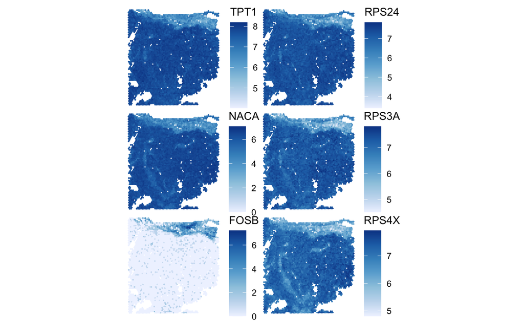

```r
Voyager::plotSpatialFeature(
  sfe,
  features = top_moran,
  ncol = 2,
  # use gene symbols instead of ensembl IDs for the plot
  swap_rownames = "Symbol"
)
```

### `nnSVG`

Let’s try `nnSVG` now, since that is more specifically designed for this kind of data.

The main advantage that it has is that it can model the spatial variation in a more flexible way, allowing for different scales of spatial variation.

We could perform this analysis on all genes, but again for now we will restrict ourselves to HVGs for time.

Note that this function works either on an SFE or an SPE object, but we will use the SFE object here since we already have it.

```r
sfe <- nnSVG::nnSVG(sfe, n_threads = 12)
```

Pause here for a break. This is much slower, but we get significance calculations by default.

```r
rowData(sfe) |>
  as.data.frame() |>
  dplyr::filter(padj < 0.05) |>
  nrow()
```

```
[1] 1916
```

Again, most of them! So most genes are significantly spatially variable, which is perhaps not a huge surprise.

Other stats we can look at include `prop_sv`, which is the proportion of variation that is attributable to spatial variation.

How do the P values compare across methods?

```r
svg_df <- rowData(sfe) |>
  as.data.frame() |>
  dplyr::select(
    ID,
    nnsvg_stat = LR_stat,
    nnsvg_propsv = prop_sv,
    nnsvg_p = pval,
    nnsvg_p_adjust = padj
  ) |>
  dplyr::mutate(
    nnsvg_neglogp = -log10(nnsvg_p)
  ) |>
  dplyr::left_join(
    moran_df,
    by = "ID"
  )
```

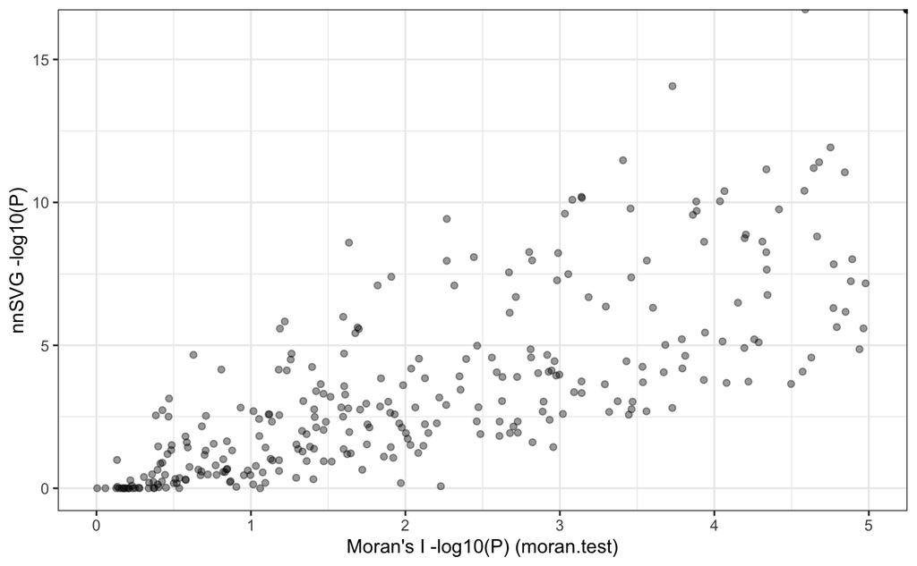

```r
ggplot(svg_df, aes(x = moran_test_neglogp, y = nnsvg_neglogp)) +
  geom_point(alpha = 0.4) +
  labs(
    x = "Moran's I -log10(P) (moran.test)",
    y = "nnSVG -log10(P)"
  ) +
  xlim(0, 5)
```

Rather than comparing just the P values, we could also look at the correlation between I and `nnsvg`’s `prop_sv` statistic.

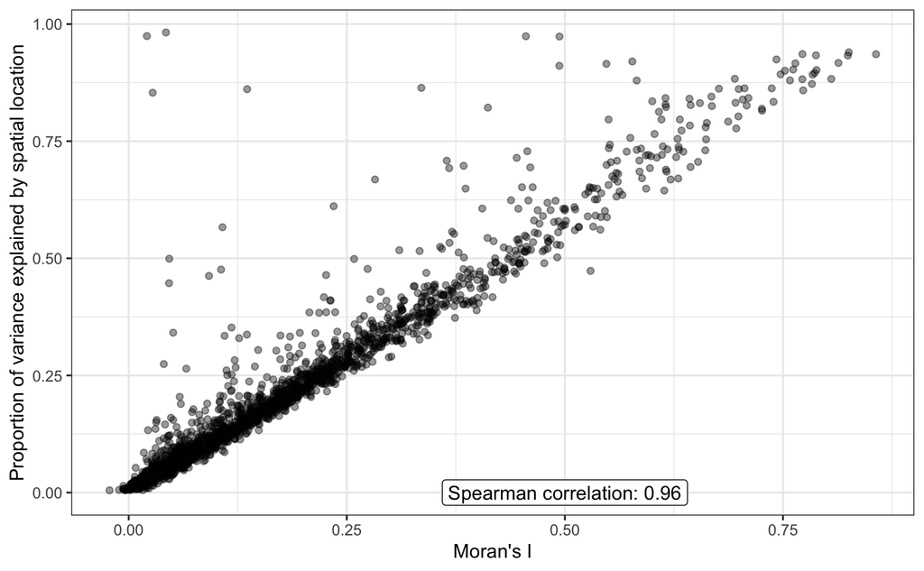

```r
ggplot(svg_df, aes(x = moran_i, y = nnsvg_propsv)) +
  geom_point(alpha = 0.4) +
  labs(
    x = "Moran's I",
    y = "Proportion of variance explained by spatial location"
  ) +
  annotate(
    geom = "label",
    x = 0.5,
    y = 0,
    label = paste0(
      "Spearman correlation: ",
      round(cor(svg_df$moran_i, svg_df$nnsvg_propsv, method = "spearman"), 2)
    )
  )
```

So for a lot of genes we get very similar scores, but `nnSVG` is uncovering some genes as spatially variable that Moran’s I does not, presumably because it models the spatial variation in a more flexible way.

Let’s look at the top few:

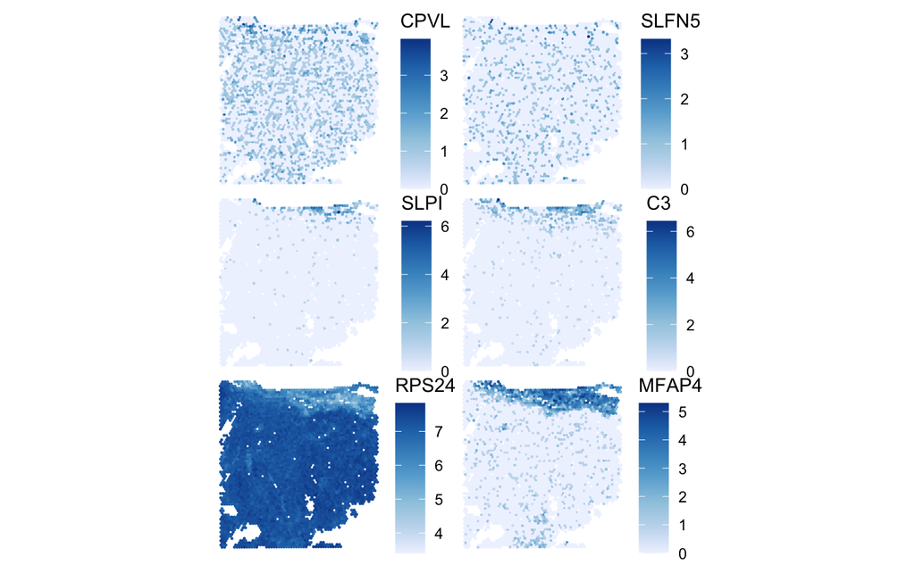

```r
top_nnsvg <- svg_df |>
  dplyr::slice_max(nnsvg_propsv, n = 6) |>
  dplyr::pull(ID)

Voyager::plotSpatialFeature(
  sfe,
  features = top_nnsvg,
  ncol = 2,
  swap_rownames = "Symbol"
)
```

This does seem to detect more punctate expression patterns, where expression of some genes is found in specific distinct spots rather than varying across larger scales.

## Looking within Regions

You may have notice that there seems to be two main areas of this slide: A top region and a lower region. As discussed in the first instruction, these may be the blastemal and stromal regions of a tumor.

Let’s do some quick clustering to see if we can detect that more broadly. We’ll use BANKSY

```r
sfe <- Banksy::computeBanksy(sfe, assay_name = "logcounts", k_geom = 18)
```

```r
sfe <- Banksy::runBanksyPCA(sfe)
```

really simple clustering: only 2 groups

```r
sfe <- Banksy::clusterBanksy(sfe, algo = "kmeans", kmeans.centers = 2)
```

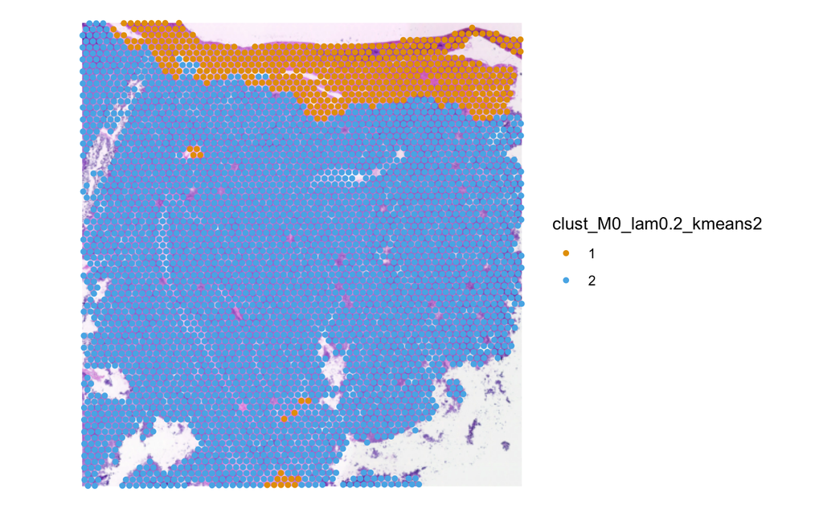

```r
Voyager::plotSpatialFeature(
  sfe,
  features = "clust_M0_lam0.2_kmeans2",
  image_id = "lowres",
  size = 1.5
)
```

The clustering here is very preliminary, but let’s see if we can use it to look at the spatially variable genes within each of these regions.

Calculate number of spots per cluster

```r
table(sfe$clust_M0_lam0.2_kmeans2)
```

```
   1    2
 510 3628
```

Let’s take the smaller cluster and see if we can detect spatially variable genes within this group of cells.

```r
small_spe <- spe[, smallclust_spots]
```

[output not shown]

```r
small_sfe <- SpatialFeatureExperiment::toSpatialFeatureExperiment(small_spe) |>
  SpatialFeatureExperiment::mirror() |>
  SpatialFeatureExperiment::mirrorImg()
```

re-find HVGs

```r
small_gene_variance <- scran::modelGeneVar(small_sfe)
small_hvg_vector <- scran::getTopHVGs(small_gene_variance, n = 2000)

small_sfe <- small_sfe[small_hvg_vector, ]
```

```r
SpatialFeatureExperiment::colGraph(
  small_sfe
) <- SpatialFeatureExperiment::findVisiumGraph(small_sfe)
```

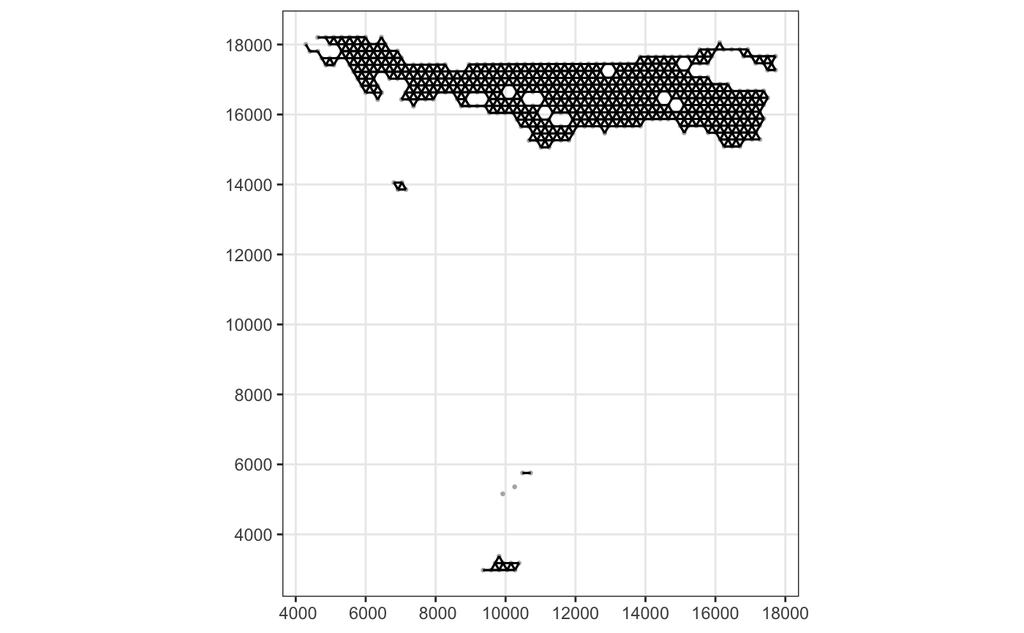

```r
Voyager::plotColGraph(small_sfe)
```

Remove “debris”, for which we will also include isolated spots that are a bit bigger.

There is some kind of bug if you do this directly on the SFE after subsetting, so we will pull out the coordinates directly for this calculation:

```r
small_debris  <- SpatialFeatureExperiment::findDebrisCells(
  SpatialFeatureExperiment::spatialCoords(small_sfe),
  distance_cutoff = 300,
  max_cells = 20
)

small_sfe <- small_sfe[, !small_debris]
```

Plot the graph for this smaller cluster

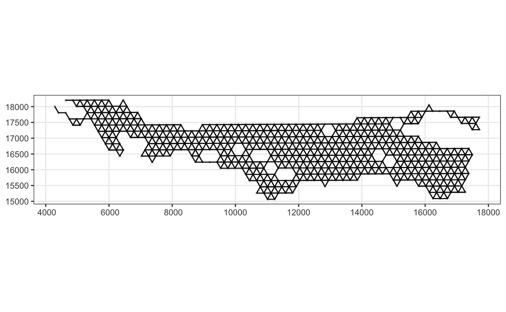

```r
Voyager::plotColGraph(small_sfe)
```

We’ll run Moran’s I and nnsvg on this SFE

```r
small_sfe <- Voyager::runMoransI(small_sfe)
small_sfe <- Voyager::runUnivariate(
  small_sfe,
  type = "moran.test",
  BPPARAM = BiocParallel::MulticoreParam(12)
)
```

```r
small_sfe <- nnSVG::nnSVG(small_sfe, n_threads = 12)
```

Pull out the results and compare to the full slide results:

```r
small_svg_df <- rowData(small_sfe) |>
  as.data.frame() |>
  dplyr::select(
    ID,
    moran_i = paste0("moran_", sample_id),
    moran_test_p = paste0("moran.test_p.value_", sample_id),
    nnsvg_stat = LR_stat,
    nnsvg_propsv = prop_sv,
    nnsvg_p = pval,
    nnsvg_p_adjust = padj
  ) |>
  dplyr::mutate(
    moran_test_neglogp = -log10(moran_test_p),
    moran_test_p_adjust = p.adjust(moran_test_p, method = "BH"),
    moran_test_sig = moran_test_p_adjust < 0.05,
    nnsvg_neglogp = -log10(nnsvg_p),
    nnsvg_sig = nnsvg_p_adjust < 0.05
  )
```

```r
small_svg_df |>
  dplyr::count(moran_test_sig, nnsvg_sig)
```

| moran_test_sig | nnsvg_sig | n |
| --- | --- | --- |
| FALSE | FALSE | 1043 |
| FALSE | TRUE | 35 |
| TRUE | FALSE | 124 |
| TRUE | TRUE | 798 |

We still see a large number of significant genes, but the number is certainly smaller than for the full slide. Some of this is probably just power though.

```r
small_top_moran <- small_svg_df |>
  dplyr::slice_max(moran_test_neglogp, n = 6) |>
  dplyr::pull(ID)

plot <- Voyager::plotSpatialFeature(
  small_sfe,
  features = small_top_moran,
  ncol = 2,
  swap_rownames = "Symbol",
)
```

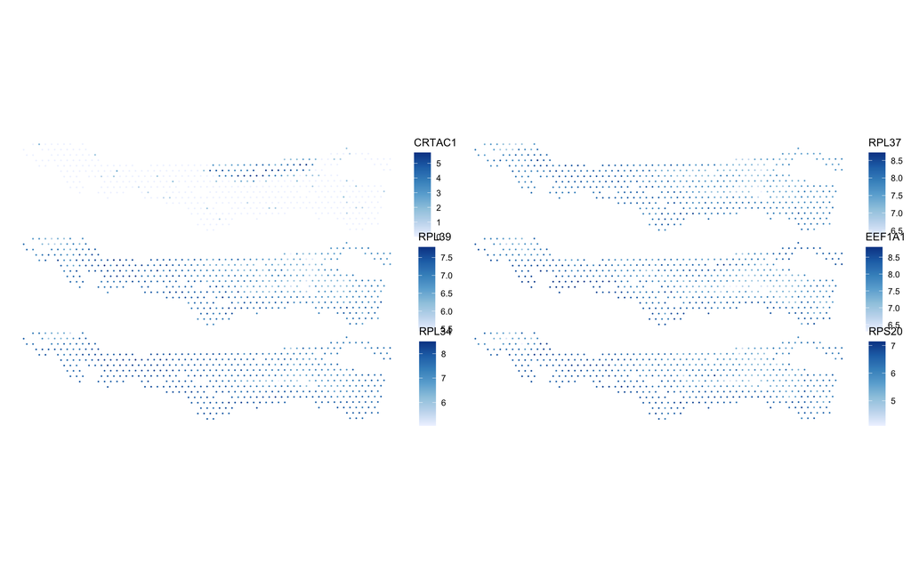

```r
#| fig.height = 8
plot
```